# Give me some credit

John (Yang Zhou)

November 8th 2015

# CSX460 Final Project

## Project Introduction

This project use the data set from kaggle competition: Give Me Some Credit, and intend to hence a convincable result by applying machine learning techniques such as Random Forest and Linear regression.

## main challenge

- Preprocess:
- Unable to handle large training data set on personal computer
- Find a efficient way to unbised sampling data
- Find best way to deal with missing values
- Feature selection and construction
- Number of variables is comparatively small due to the unsensitivity to variable dimensions of Random Forest algorithm, which make feature selection as well as feature construction crutial in this project
- Model Tuning
- Number of trees
- Number of variables randomly sampled as candidates at each split
- Number of features

# Part One: Data preprocessing

### Getting started

```r
library(caret)
library(party)
```

```r
library(ggplot2)
library(magrittr)
library(pROC)
set.seed(314159)

setwd("D:/学习资料/UCB上/Practical of machine learning in R/CSX460/PROJECT")

train_data <- read.csv("cs-training.csv")

#remove the row name column
train_data <- train_data[,-1]
```

### double sampling data due to large data set (unbiased)

```r
#choose good and bad seperately
bad <- train_data[which(train_data$SeriousDlqin2yrs==1),]

good <- train_data[-which(train_data$SeriousDlqin2yrs==1),]

#take equal numbers of data from both good and bad(randomly and unbiased)
bad_sample_nrow <- sort(sample(nrow(bad),size=1000))

bad_sample <- bad[c(bad_sample_nrow),]

good_sample_nrow <- sample(nrow(good),size=1000)

good_sample <- good[c(good_sample_nrow),]

#conbine the two set of good and bad data
onepercent_sample_train_data <- rbind(bad_sample, good_sample)


#partition training data into train and valid
sample_train_data_nrow <- sort(sample(nrow(train_data), size=nrow(train_data)*0.7))

sample_train_data <- train_data[c(sample_train_data_nrow),]

sample_valid_data <- train_data[-c(sample_train_data_nrow),]

#copy data set for linear regression
linear_train_data <- onepercent_sample_train_data

#transform the target column into factor in order to make random forest work
onepercent_sample_train_data$SeriousDlqin2yrs <- as.factor(onepercent_sample_train_data$SeriousDlqin2yrs)
```

### Remove Redundant Features

```r
# calculate correlation matrix
correlationMatrix <- cor(train_data[,2:11])

# summarize the correlation matrix(show the interconnecttion or influence between each variables)
print(correlationMatrix)
```

```
##                                      RevolvingUtilizationOfUnsecuredLines
## RevolvingUtilizationOfUnsecuredLines                          1.000000000
## age                                                          -0.005898183
## NumberOfTime30.59DaysPastDueNotWorse                         -0.001313501
## DebtRatio                                                     0.003961205
## MonthlyIncome                                                          NA
## NumberOfOpenCreditLinesAndLoans                              -0.011280733
## NumberOfTimes90DaysLate                                      -0.001061246
## NumberRealEstateLoansOrLines                                  0.006234713
## NumberOfTime60.89DaysPastDueNotWorse                         -0.001047827
## NumberOfDependents                                                     NA
##                                               age
## RevolvingUtilizationOfUnsecuredLines -0.005898183
## age                                   1.000000000
## NumberOfTime30.59DaysPastDueNotWorse -0.062995158
## DebtRatio                             0.024187804
## MonthlyIncome                                  NA
## NumberOfOpenCreditLinesAndLoans       0.147705318
## NumberOfTimes90DaysLate              -0.061004708
## NumberRealEstateLoansOrLines          0.033150273
## NumberOfTime60.89DaysPastDueNotWorse -0.057159464
## NumberOfDependents                             NA
##                                      NumberOfTime30.59DaysPastDueNotWorse
## RevolvingUtilizationOfUnsecuredLines                         -0.001313501
## age                                                          -0.062995158
## NumberOfTime30.59DaysPastDueNotWorse                          1.000000000
## DebtRatio                                                    -0.006541923
## MonthlyIncome                                                          NA
## NumberOfOpenCreditLinesAndLoans                              -0.055312236
## NumberOfTimes90DaysLate                                       0.983602681
## NumberRealEstateLoansOrLines                                 -0.030564535
## NumberOfTime60.89DaysPastDueNotWorse                          0.987005447
## NumberOfDependents                                                     NA
##                                         DebtRatio MonthlyIncome
## RevolvingUtilizationOfUnsecuredLines  0.003961205            NA
## age                                   0.024187804            NA
## NumberOfTime30.59DaysPastDueNotWorse -0.006541923            NA
## DebtRatio                             1.000000000            NA
## MonthlyIncome                                  NA             1
## NumberOfOpenCreditLinesAndLoans       0.049565286            NA
```

[output cut: 44 more lines]

```
## NumberOfTimes90DaysLate                                       0.992796183
## NumberRealEstateLoansOrLines                                 -0.039722332
## NumberOfTime60.89DaysPastDueNotWorse                          1.000000000
## NumberOfDependents                                                     NA
##                                      NumberOfDependents
## RevolvingUtilizationOfUnsecuredLines                 NA
## age                                                  NA
## NumberOfTime30.59DaysPastDueNotWorse                 NA
## DebtRatio                                            NA
## MonthlyIncome                                        NA
## NumberOfOpenCreditLinesAndLoans                      NA
## NumberOfTimes90DaysLate                              NA
## NumberRealEstateLoansOrLines                         NA
## NumberOfTime60.89DaysPastDueNotWorse                 NA
## NumberOfDependents                                    1
```

```r
# find attributes that are highly correlated (ideally >0.75)
highlyCorrelated <- findCorrelation(correlationMatrix, cutoff=0.75)
```

```
## [1] 7 9
```

```r
#remove the high coreelated attributes
onepercent_sample_train_data <- onepercent_sample_train_data[,-highlyCorrelated]
```

### rank feature importance

```r
# prepare training scheme
control <- trainControl(method="repeatedcv", number=10, repeats=3)

# train the model
model <- train(SeriousDlqin2yrs~., data=onepercent_sample_train_data, method="lvq", preProcess="scale", trControl=control)
# estimate variable importance
importance <- varImp(model, scale=FALSE)
```

```
## ROC curve variable importance
##
##                                      Importance
## RevolvingUtilizationOfUnsecuredLines     0.7696
## NumberOfTime30.59DaysPastDueNotWorse     0.6842
## NumberOfTimes90DaysLate                  0.6357
## NumberOfTime60.89DaysPastDueNotWorse     0.6217
## age                                      0.6186
## MonthlyIncome                            0.5753
## NumberOfDependents                       0.5449
## DebtRatio                                0.5164
```

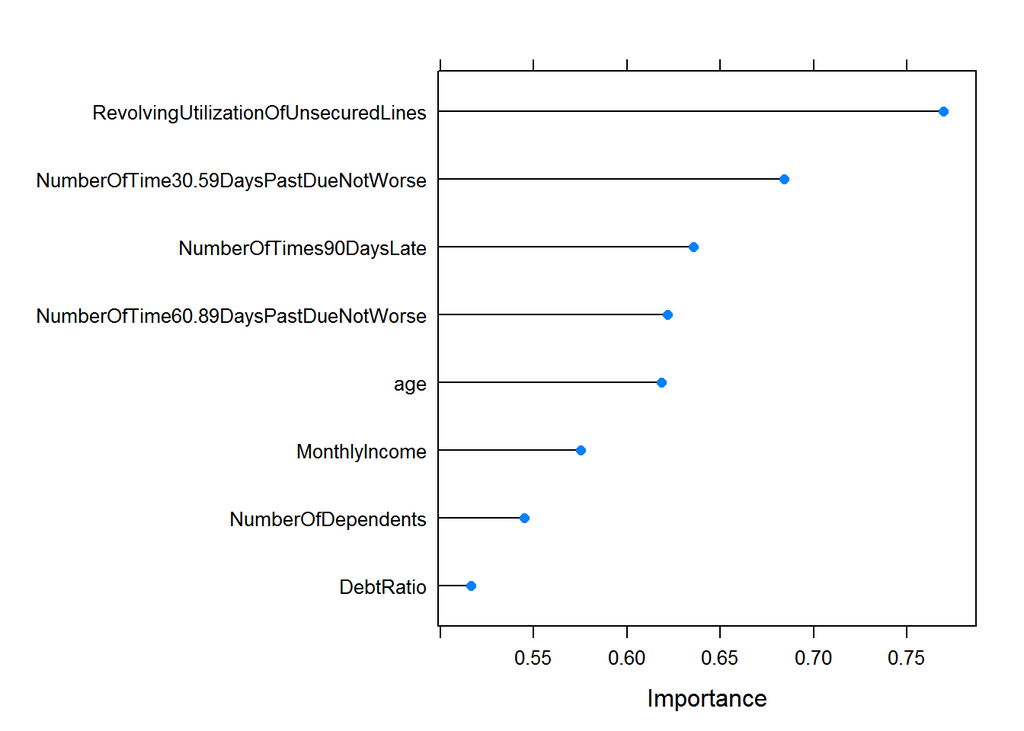

### preprocessing by deal with missing value and feature selection

```r
#Replacing Missing Values with column mean
for(i in 2:ncol(onepercent_sample_train_data)){
  onepercent_sample_train_data[is.na(onepercent_sample_train_data[,i]), i] <- mean(onepercent_sample_train_data[,i], na.rm = TRUE)
}

# define the control using a random forest selection function for cross validation feature selection
control <- rfeControl(functions=rfFuncs, method="cv", number=5)

# run the RFE algorithm
results <- rfe(x=onepercent_sample_train_data[,2:9], y=onepercent_sample_train_data[,1], sizes=c(2:9), rfeControl=control)
```

```
##
## Recursive feature selection
##
## Outer resampling method: Cross-Validated (5 fold)
##
## Resampling performance over subset size:
##
##  Variables Accuracy Kappa AccuracySD KappaSD Selected
##          2   0.7310 0.462   0.025037 0.05007
##          3   0.7445 0.489   0.014727 0.02945
##          4   0.7495 0.499   0.019953 0.03991
##          5   0.7565 0.513   0.013987 0.02797
##          6   0.7590 0.518   0.014853 0.02971
##          7   0.7620 0.524   0.016808 0.03362        *
##          8   0.7590 0.518   0.008944 0.01789
##
## The top 5 variables (out of 7):
##    RevolvingUtilizationOfUnsecuredLines, NumberOfTime60.89DaysPastDueNotWorse, NumberOfTime30.59DaysPastDueNotWorse, NumberOfTimes90DaysLate, MonthlyIncome
```

```
## [1] "RevolvingUtilizationOfUnsecuredLines"
## [2] "NumberOfTime60.89DaysPastDueNotWorse"
## [3] "NumberOfTime30.59DaysPastDueNotWorse"
## [4] "NumberOfTimes90DaysLate"
## [5] "MonthlyIncome"
## [6] "DebtRatio"
## [7] "age"
```

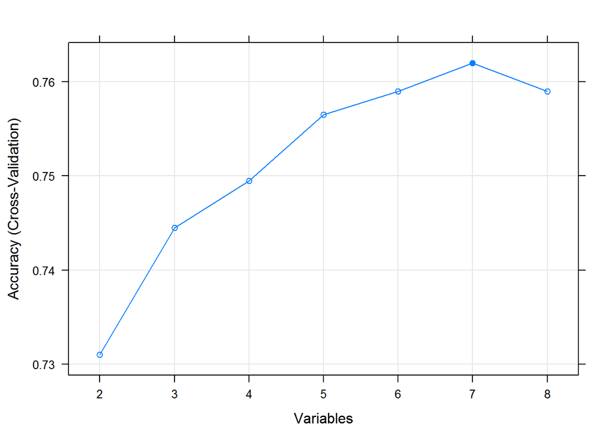

#### From the plot, we can see that when taking 7 number of features in the model building, the random forest can give the better prediction.

# Part Two: Random Forest Model Building

- linear regression: finding feature conbinations

```r
for(i in 1:ncol(linear_train_data)){
  linear_train_data[is.na(linear_train_data[,i]), i] <- mean(linear_train_data[,i], na.rm = TRUE)
}

# transform data
linear_train_data$SeriousDlqin2yrs <- (linear_train_data$SeriousDlqin2yrs - 1) %>% as.logical

#cross validation
linear_model1 <- glm( SeriousDlqin2yrs ~ . , data=linear_train_data, family="binomial")
linear_model2 <- glm( SeriousDlqin2yrs ~ (.)^2, data=linear_train_data,  family="binomial")
```

```
##
## Call:
## glm(formula = SeriousDlqin2yrs ~ ., family = "binomial", data = linear_train_data)
##
## Deviance Residuals:
##     Min       1Q   Median       3Q      Max
## -3.0279  -1.0646   0.0313   1.0069   8.4904
##
## Coefficients:
##                                        Estimate Std. Error z value
## (Intercept)                          -1.034e+00  2.005e-01  -5.158
## RevolvingUtilizationOfUnsecuredLines  4.258e-04  4.651e-04   0.915
## age                                   2.695e-02  3.678e-03   7.328
## NumberOfTime30.59DaysPastDueNotWorse -4.944e-01  5.795e-02  -8.533
## DebtRatio                             4.620e-05  3.344e-05   1.381
## MonthlyIncome                         1.577e-05  1.135e-05   1.390
## NumberOfOpenCreditLinesAndLoans       1.773e-02  1.036e-02   1.712
## NumberOfTimes90DaysLate              -3.375e-01  6.923e-02  -4.875
## NumberRealEstateLoansOrLines         -1.358e-01  4.210e-02  -3.225
## NumberOfTime60.89DaysPastDueNotWorse -5.925e-02  1.004e-01  -0.590
## NumberOfDependents                   -3.678e-02  4.223e-02  -0.871
##                                      Pr(>|z|)
## (Intercept)                          2.50e-07 ***
## RevolvingUtilizationOfUnsecuredLines  0.35996
## age                                  2.34e-13 ***
## NumberOfTime30.59DaysPastDueNotWorse  < 2e-16 ***
## DebtRatio                             0.16716
## MonthlyIncome                         0.16456
## NumberOfOpenCreditLinesAndLoans       0.08683 .
## NumberOfTimes90DaysLate              1.09e-06 ***
## NumberRealEstateLoansOrLines          0.00126 **
## NumberOfTime60.89DaysPastDueNotWorse  0.55498
## NumberOfDependents                    0.38375
## ---
## Signif. codes:  0 '***' 0.001 '**' 0.01 '*' 0.05 '.' 0.1 ' ' 1
##
## (Dispersion parameter for binomial family taken to be 1)
##
##     Null deviance: 2772.6  on 1999  degrees of freedom
## Residual deviance: 2383.7  on 1989  degrees of freedom
## AIC: 2405.7
##
## Number of Fisher Scoring iterations: 8
```

```
##
## Call:
## glm(formula = SeriousDlqin2yrs ~ (.)^2, family = "binomial",
##     data = linear_train_data)
##
## Deviance Residuals:
##     Min       1Q   Median       3Q      Max
## -2.4273  -0.8539   0.0000   0.8074   3.2678
##
## Coefficients:
##                                                                             Estimate
## (Intercept)                                                               -3.115e-01
## RevolvingUtilizationOfUnsecuredLines                                      -8.580e-02
## age                                                                        1.785e-02
## NumberOfTime30.59DaysPastDueNotWorse                                      -8.566e-01
## DebtRatio                                                                 -2.023e-04
## MonthlyIncome                                                              1.426e-05
## NumberOfOpenCreditLinesAndLoans                                           -2.511e-03
## NumberOfTimes90DaysLate                                                   -1.927e+00
## NumberRealEstateLoansOrLines                                               2.994e-01
## NumberOfTime60.89DaysPastDueNotWorse                                       5.025e-01
## NumberOfDependents                                                         6.071e-02
## RevolvingUtilizationOfUnsecuredLines:age                                  -2.912e-03
## RevolvingUtilizationOfUnsecuredLines:NumberOfTime30.59DaysPastDueNotWorse  1.177e-01
## RevolvingUtilizationOfUnsecuredLines:DebtRatio                             3.570e-04
## RevolvingUtilizationOfUnsecuredLines:MonthlyIncome                        -2.575e-06
## RevolvingUtilizationOfUnsecuredLines:NumberOfOpenCreditLinesAndLoans       3.647e-02
## RevolvingUtilizationOfUnsecuredLines:NumberOfTimes90DaysLate              -4.382e-02
## RevolvingUtilizationOfUnsecuredLines:NumberRealEstateLoansOrLines         -1.731e-01
## RevolvingUtilizationOfUnsecuredLines:NumberOfTime60.89DaysPastDueNotWorse -1.204e+00
## RevolvingUtilizationOfUnsecuredLines:NumberOfDependents                   -6.954e-01
## age:NumberOfTime30.59DaysPastDueNotWorse                                  -4.989e-03
## age:DebtRatio                                                              1.005e-05
## age:MonthlyIncome                                                         -1.961e-07
## age:NumberOfOpenCreditLinesAndLoans                                        7.198e-04
## age:NumberOfTimes90DaysLate                                                2.210e-02
## age:NumberRealEstateLoansOrLines                                           1.611e-03
## age:NumberOfTime60.89DaysPastDueNotWorse                                  -1.910e-02
## age:NumberOfDependents                                                     6.354e-03
## NumberOfTime30.59DaysPastDueNotWorse:DebtRatio                            -1.439e-04
```

[output cut: 250 more lines]

```
## NumberOfTimes90DaysLate:NumberOfTime60.89DaysPastDueNotWorse              ***
## NumberOfTimes90DaysLate:NumberOfDependents
## NumberRealEstateLoansOrLines:NumberOfTime60.89DaysPastDueNotWorse
## NumberRealEstateLoansOrLines:NumberOfDependents                           .
## NumberOfTime60.89DaysPastDueNotWorse:NumberOfDependents                   *
## ---
## Signif. codes:  0 '***' 0.001 '**' 0.01 '*' 0.05 '.' 0.1 ' ' 1
##
## (Dispersion parameter for binomial family taken to be 1)
##
##     Null deviance: 2772.6  on 1999  degrees of freedom
## Residual deviance: 1992.4  on 1944  degrees of freedom
## AIC: 2104.4
##
## Number of Fisher Scoring iterations: 13
```

```r
#only use the features that are seleceted
sample_train_data$SeriousDlqin2yrs <- as.factor(sample_train_data$SeriousDlqin2yrs)

#Replacing Missing Values with column mean
for(i in 2:ncol(sample_train_data)){
  sample_train_data[is.na(sample_train_data[,i]), i] <- mean(sample_train_data[,i], na.rm = TRUE)
}
#random forest model training

rf_model <- randomForest(SeriousDlqin2yrs ~ NumberOfTime60.89DaysPastDueNotWorse
                    +RevolvingUtilizationOfUnsecuredLines
                    +NumberOfTime30.59DaysPastDueNotWorse
                    +NumberOfTimes90DaysLate
                    +RevolvingUtilizationOfUnsecuredLines
                    +age
                    +RevolvingUtilizationOfUnsecuredLines*DebtRatio
                    +RevolvingUtilizationOfUnsecuredLines*NumberOfDependents
                    +RevolvingUtilizationOfUnsecuredLines*age
                    +NumberOfTime30.59DaysPastDueNotWorse*NumberOfTime60.89DaysPastDueNotWorse
                    +NumberOfTime30.59DaysPastDueNotWorse*NumberOfTime30.59DaysPastDueNotWorse
                    +NumberOfOpenCreditLinesAndLoans*NumberRealEstateLoansOrLines
                    +NumberOfTimes90DaysLate*NumberOfTime60.89DaysPastDueNotWorse, data=sample_train_data, importance=TRUE, ntree=100)
```

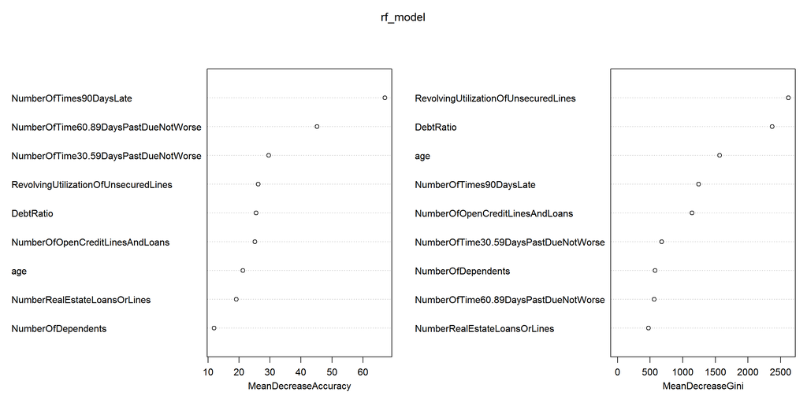

```r
varImpPlot(rf_model)
```

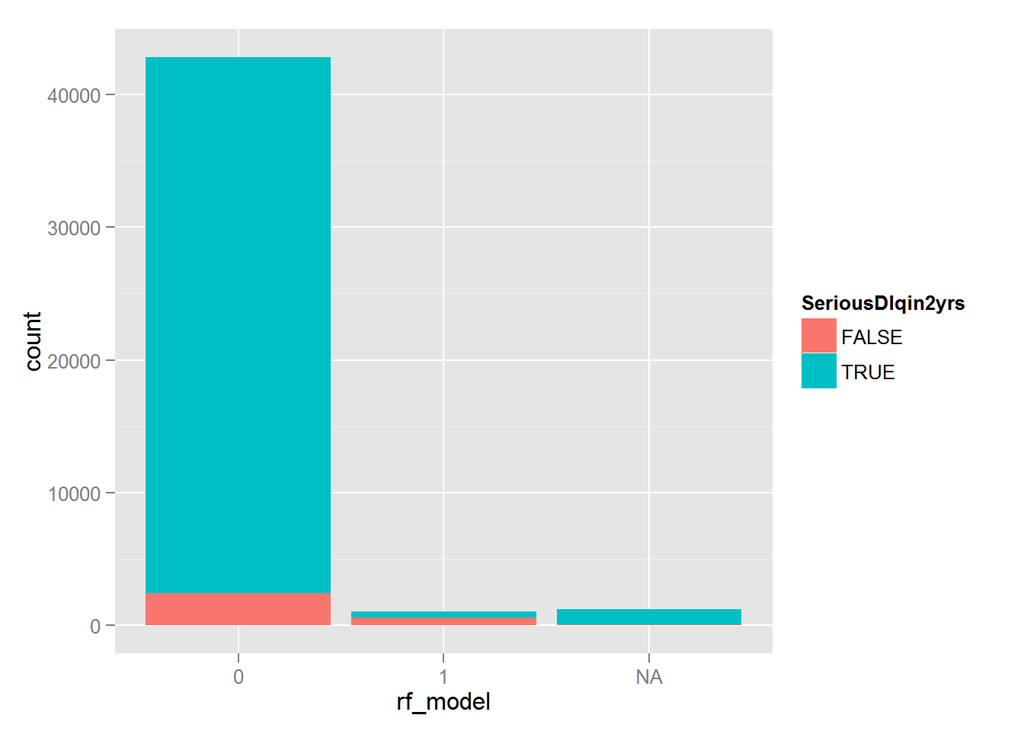

```r
#model outcome Validation
sample_valid_data$rf_model <-
  predict(rf_model, sample_valid_data, type="response") # > 0.5

# transform data
sample_valid_data$SeriousDlqin2yrs <- (sample_valid_data$SeriousDlqin2yrs - 1) %>% as.logical

#Plot
qplot( x=rf_model, data=sample_valid_data, fill=SeriousDlqin2yrs )
```

```r
#TF Matrix
sample_valid_data$rf_model.class <-
  as.numeric(predict(rf_model, sample_valid_data, type="response"))-1 > 0.5
```

> From the plot,we can see that the possibility of this model detecting the True Negative is comparative low due low small number of training sample.

```
##
##         FALSE  TRUE
##   FALSE  2412   561
##   TRUE  40404   445
```

```r
#accuracy
( accuracy = sum(diag(tab))/sum(tab) )
```

```
## [1] 0.06519556
```

```r
#error rate
1- accuracy
```

```
## [1] 0.9348044
```